# comparing similarity measures: simulations

michael freund

4/28/2020

# intro

## purpose

1. sanity check: verify that i’ve implemented the various similarity measures correctly by using the same RSA pipeline code on data where ground truth is known
2. proof of concept: illustrate that using “cross-validated” measures may give us a way to get around trial balancing issues (i.e., differing numbers of trials across conditions).

I generate data with a known similarity structure, then fit GLMs and recover this structure using various measures of similarity.

## data-generating process

Here’s the basic model. Matrices corresponding to these descriptions are located under general parameters.

**1. Create the signal, **G** (for geometry), and the noise structure, $\Sigma$.** Both of these are covariance matrices.

- $\mathbf{G}:$ a $C$ (number of conditions) $\times C$ covariance matrix. What we want to recover in RSA.
- $\mathbf{\Sigma}:$ a $V$ (number of voxels) $\times \textit{V}$ covariance matrix. Indicates the spatial structure of the non-signal variance within an ROI.
  - This is what spatial pre-whitening attempts to remove.
  - Here, I assumed the noise covariance fell off as a function of ‘spatial distance’ (i.e., in row/column indices), and that this function was a Gaussian kernel.
  - To manipulate SNR, I multiplied $\Sigma$ by a scalar value (while keeping **G** constant).

**2. Create B: the matrix that defines how the geometry is realized in a given set of voxels.**

- $\mathbf{B}:$ a $V \times C$ matrix.
- Each row of **B** indicates the true response of the voxel to each task condition.
- This is what we’d like to recover in the GLM.
- To generate this I drew voxels from a multivariate distribution with mean vector $\mu_C = \mathbf{0}$ and covariance matrix $\mathbf{G}$.
  - i.e., for voxel $v$, (a row of the **B** matrix), $\mathbf{B}_v \sim N_C(\mathbf{0}, \mathbf{G})$

**3. Create X: design matrix**

- $\mathbf{X}:$ a $\textit{T}$ (number of TRs) $\times \textit{C}$ binary matrix.
- events indicated by 1
- all columns (condition regressors) orthogonal

**4. Create Y: raw voxel timecourses**

- $\mathbf{Y} = \mathbf{XB} + \epsilon_{T\times V}$, where each row of $\epsilon$ (each TR) is a draw $\sim N_V(\mathbf{0}, \Sigma)$

## estimation process

**1. Estimate B via OLS**

- $\hat{\mathbf{B}} = (\mathbf{X}^T\mathbf{X})^{-1}\mathbf{X}^T\mathbf{Y}$

**2. Estimate G via RSA**

- Here I used **3 measures of similarity**
  1. linear correlation
  2. euclidean distance (squared)
  3. standardized euclidean distance (squared)
     - where the pattern vectors are z-score standardized prior to calculating euclidean’s distance
     - renders the resulting euclidean proportional to linear correlation
- … crossed with… **2 normalization procedures**, conducted on pattern estimates $\hat{\mathbf{B}}$
  1. unnormalized, or **“raw”**
  2. spatially prewhitened (aka ‘multivariate noise normalized’), or **“white”**
     - normalized by multiplying by the inverse of the residual (vertex by vertex) covariance matrix
- … crossed with… **2 methods of estimation**
  1. ‘vanilla’
     - standard between-run estimation
     - yields true distance measures and true correlation statistics
     - e.g., $r_\mathit{x, y} = [\text{cor}(x_\mathit{run 1}, y_\mathit{run 2}) + \text{cor}(x_\mathit{run 2}, y_\mathit{run 1})] / 2$
  2. ‘cross-validated’
     - non-standard estimation
     - yields unbiased measures: expected value centered at true value of similarity
     - however these measures are technically no longer distance measures, nor correlation statistics
       - “cross-validated linear correlation” is not bounded within the range [-1, 1]
       - “cross-validated euclidean” can be negative

For detailed descriptions of these measures, see the RMD within the **./analyses/comparing_similarity_measures_empirical/.** directory (currently in development).

## general parameters (fixed across simulations)

- number of subjects (independent simulations): 30
  - for each subject, **B** and $\epsilon$ were simulated anew
- number of voxels: 100
- number of conditions: 20
- number of TRs: 1000
- number of scanning runs: 2
- amount of spatial auto-correlation (width of kernel for noise covariance $\Sigma$): 0.9

## general notes

- to make correlation and euclidean distances more easily comparable, all euclidean distances were negated
- The cross-validated correlation has the potential to be undefined (as result of negative square root, or zero, in denominator). In even small to moderate amounts of noise, the measure can become unstable (as was the case here). To run the same plots / stats on these cross-validated correlations, I set all NaN values equal to zero. This is obviously not ideal. For interpreting the simulation results, don’t focus on cross-validated correlation.

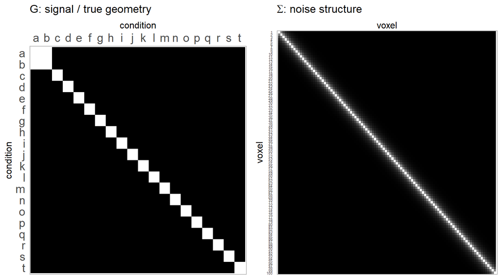

# simulation 1: balanced design, high SNR

Just to show that, under unrealistically high SNR, these methods all recover the correct geometry.

## parameters

- number of TRs per condition: 10
- snr: 1

## results: similarity matrices

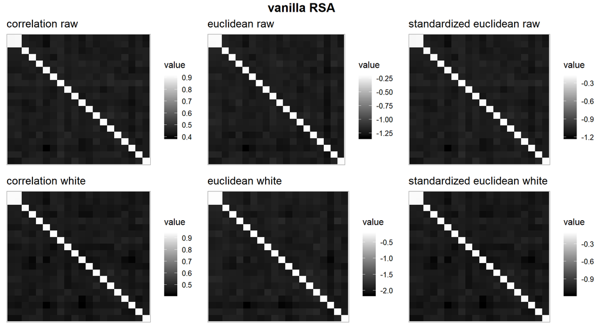

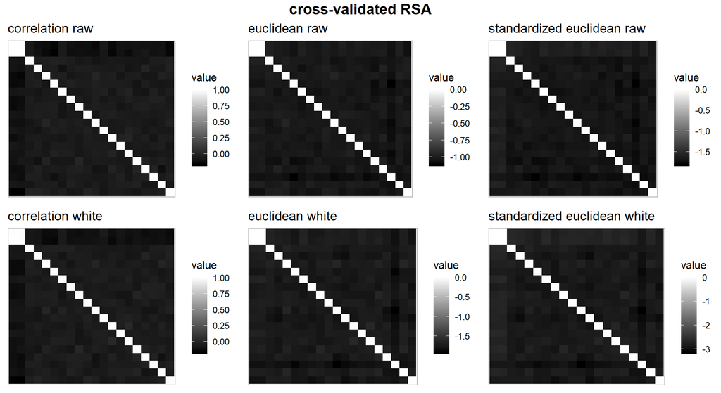

# simulation 2: balanced design, range of SNRs

How do these measures behave as a function of SNR?

## parameters

- range of snrs tested: 1, 400
- number of TRs per condition: 10

## results: similarity matrices

### 1/50 SNR

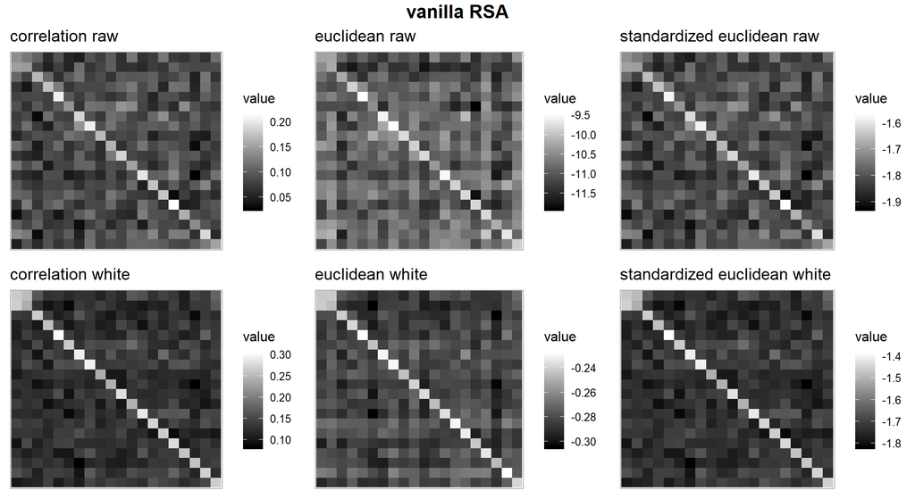

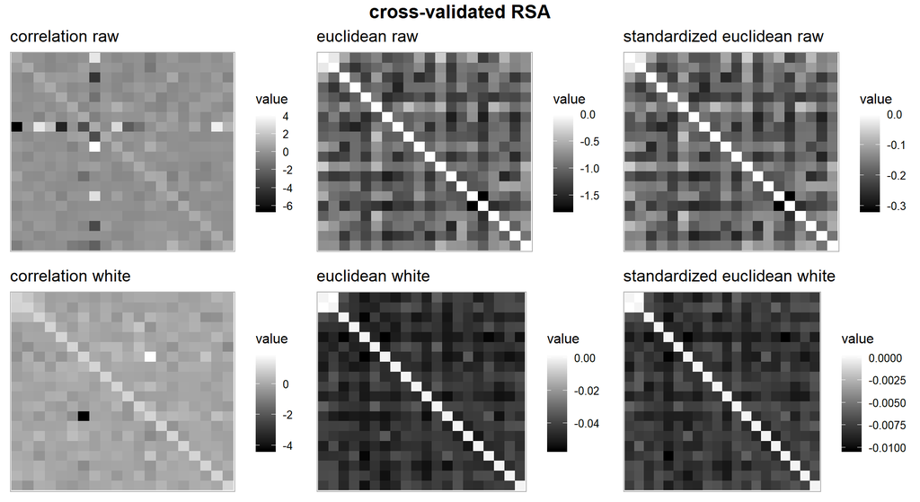

### 1/100 SNR

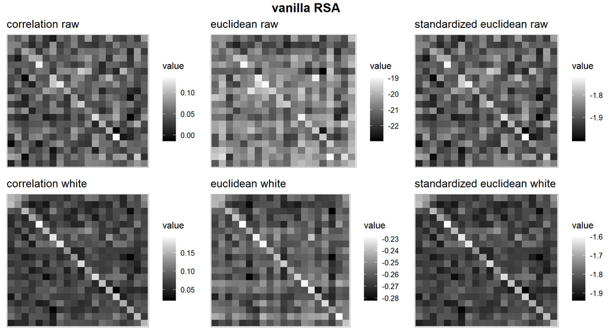

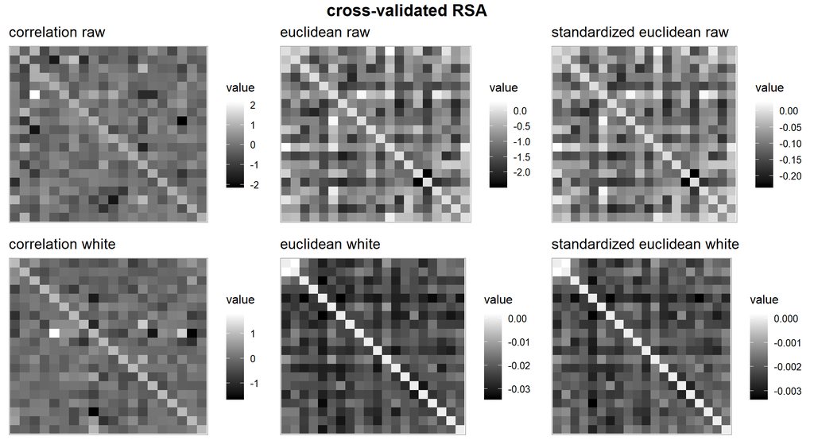

### 1/400 SNR

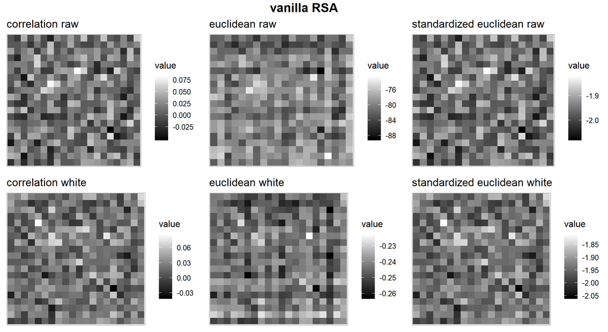

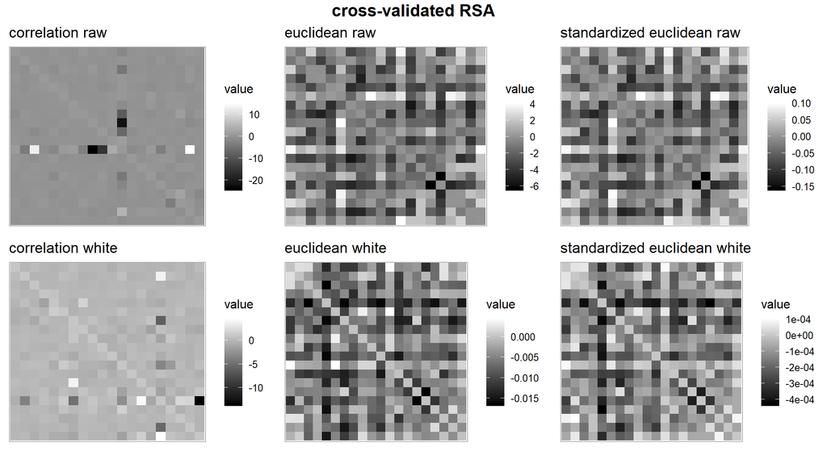

## results: RSA model fits (mean contrasts)

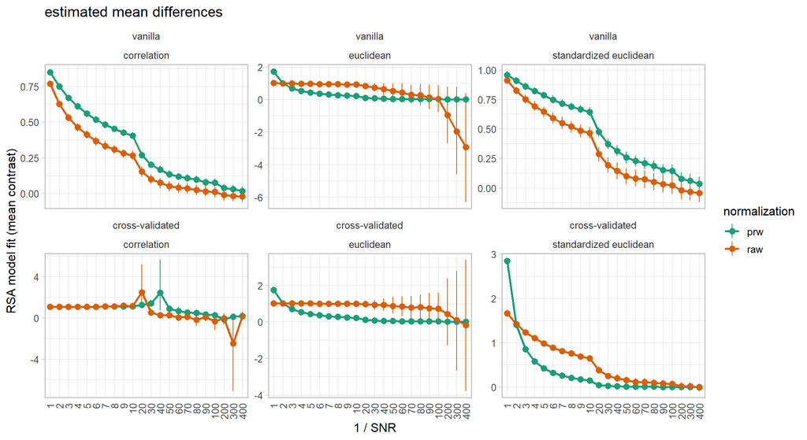

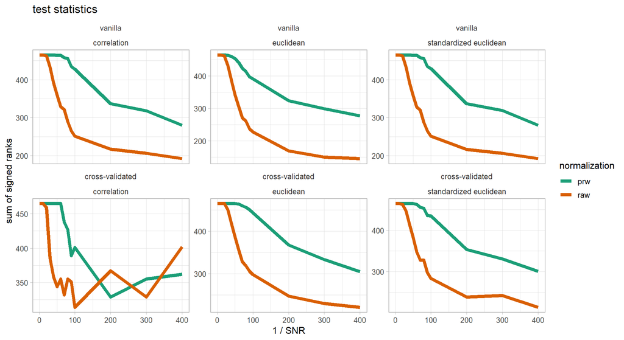

### notes

# simulation 3: unbalanced designs, range of SNR

Cross-validated measures of similarity are ‘unbiased’: their expected value is the true value. This should mean that the mean of these measures does not depend on the SNR, or on the number of trials that feed into the pattern estimates. If unbiased measures are insensitive to number of trials / TRs, then they would be useful in imbalanced designs (like ours).

Here I increase the number of TRs within a single condition, **condition t**, while keeping the TRs for other conditions constant. I run this trial number simulation at a few different SNRs.

## parameters

Consistent with similarity matrices, white indicates maximum (1), black indicates minimum (0).

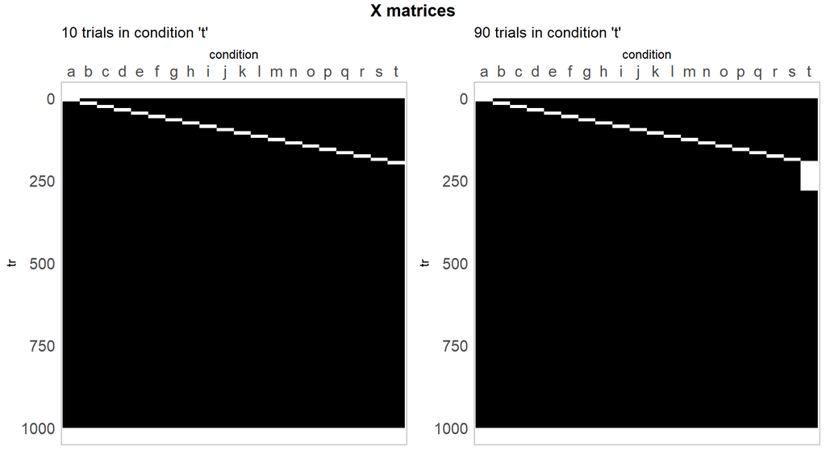

- range of snrs tested: 1, 100
- range of number of TRs in condition *t* tested: 10, 90
- number of TRs in other conditions: 10

## results: similarity matrices

Just an example from a single SNR and number of TRs:

#### 1/SNR = 50, number of TRs in ‘t’ = 50

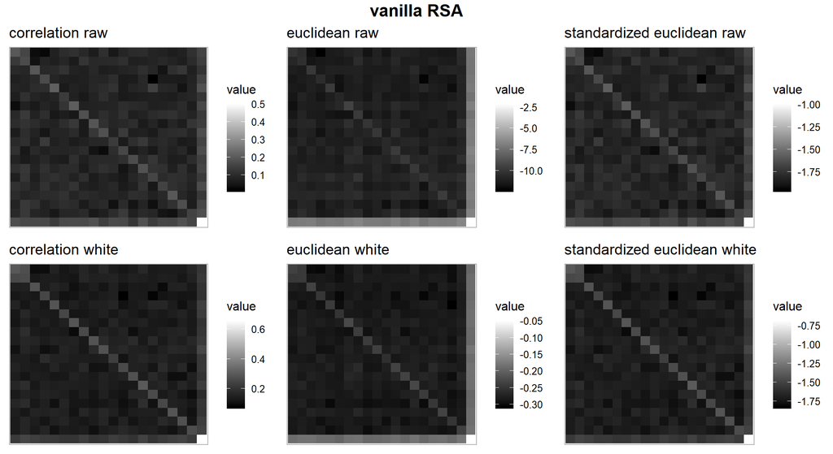

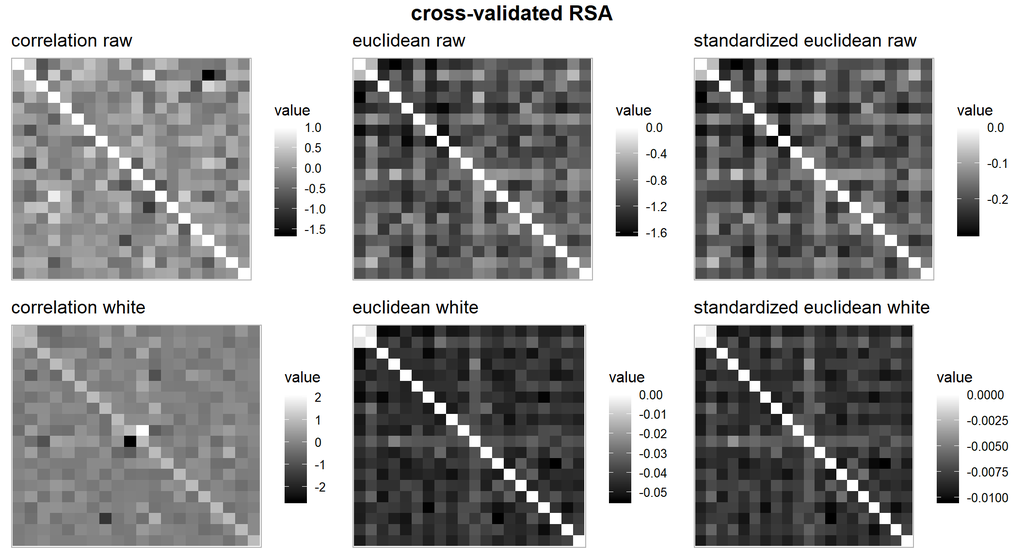

### notes

- the bias–variance trade-off here is clear.
- “vanilla” measures
  - there are clear stripes corresponding to condition ‘t’: high bias
  - however, looking across the rest of the matrix, the cells are relatively evenly shaded: low variance
- “cross-validated” measures
  - the stripes of condition ‘t’ disappear: low bias
  - however, there is much less smoothness in shade across the matrix: high variance
- no free lunch

## results: similarities (cell-wise means)

For simplicity I only display prewhitened measures.

### vanilla measures

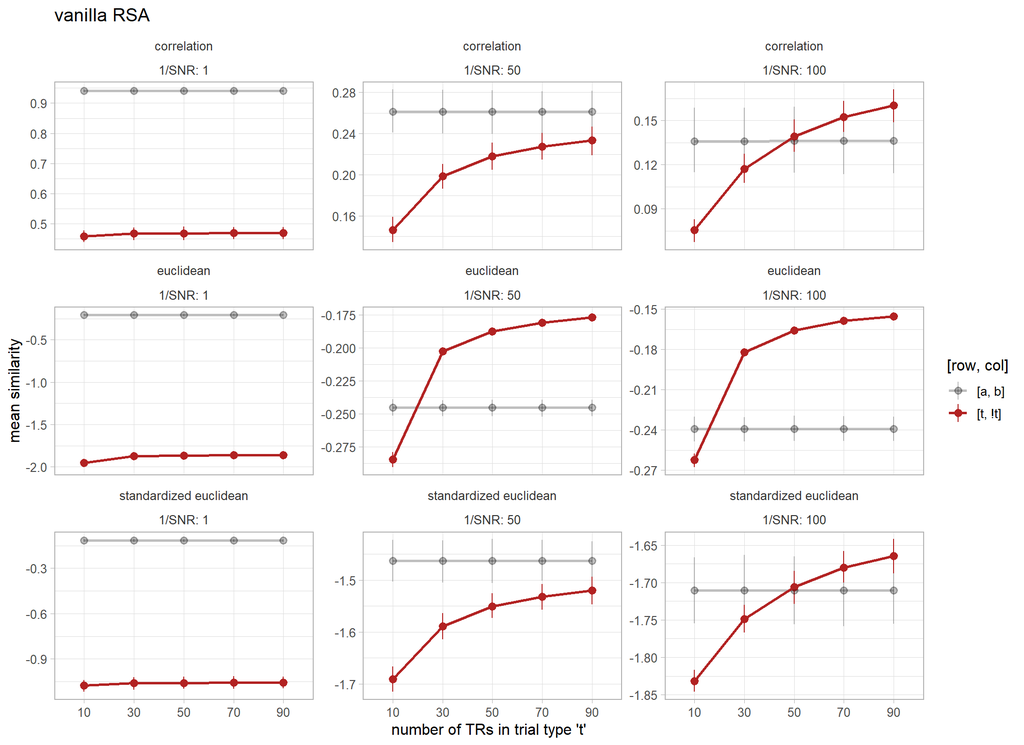

#### notes

- in high SNR scenarios (left panels), measurements are already close to their true values. I.e., correlation of trial types *a* and *b* are near 1; *t* and all other trial types (*!t*) are near 0.5.
- thus, in high SNR, the number of trials in *t* has little impact on similarity measures.
- because the ‘true’ correlation between *a* and *b* is 1, we can view the grey [*a*, *b*] line as the ‘noise ceiling’. I.e., the highest correlation observable, given the SNR, and the number of trials in *a* and *b* (here, 10).
- when decreasing SNR (moving right across panels), note that the y axis scale of the graphs decreases. I.e., with the correlation, the grey [*a*, *b*] line approaches zero. The noise ceiling is lowered.
- In lower SNR scenarios, the magnitude (mean) of the measures become much more sensitive to the number of trials within each trial type. This is seen as the increasing red [*t*, *!t*] line across the graphs. (note however that the variances of these measures, indicated by the error bars, remains relatively stable across different trial counts.)
- Eventually the observed [*t*, *!t*] similarity becomes greater than the [*a*, *b*] similarity, despite the true similarity being much less (e.g., r = 0.5 compared to r = 1). The key ingredients for this effect are:
  - relatively **low SNR** (low upper-bound on similarities)
  - a positive level of **“baseline” similarity**; i.e., trial types that are not predicted to be similar (because of theory) nevertheless evoke *somewhat* similar patterns (here, the baseline was r = 0.5)
  - **differing numbers of trials** between conditions of interest.
- under equivalent SNR scenarios, euclidean’s distance seems particularly sensitive to trial counts relative to correlation-like measures (correlation, standardized euclidean). not sure what to make of this, but interesting to note.

### cross-validated measures

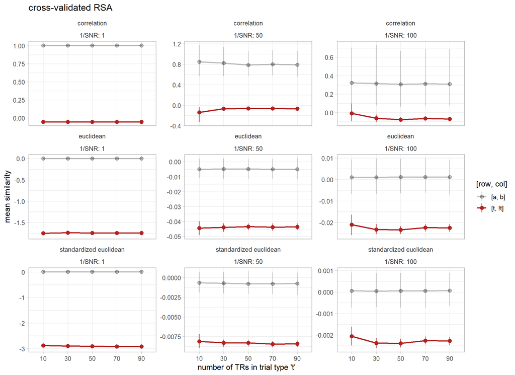

#### notes

- *note that the “cross-validated correlation” results here are not very interpretable: all cells with undefined correlations (as a result of variances $\leq 0$) were replaced with 0.* **focus instead on euclidean and standardized euclidean to interpret results**
- the picture is different with cross-validated measures
- first thing to note is that the SNR / number of trials does not impact the expected value of the similarity measure. For example, the ‘noise ceiling’ correlations ([*a*, *b*]) are roughly centered on zero (identical) in the euclidean distance and the standardized euclidean for all plots.
- what number of trials *does* impact is the variances. this can be seen as increasing error bars from left to right across panels (with SNR decreasing), or as decreasing error bars of the red [*t*, *!t*] lines within each plot (with trial counts increasing).
- also note that SNR impacts the *scale* of each plot. I.e., although identical patterns are centered at zero (grey line) across the board, patterns with r = 0.5 (red line) are located increasingly nearer to zero with decreasing SNR (red line approaches grey line from L to R panels). In other words, the only absolutely meaningful value in these measures is zero. the ratio of measures is defined by the SNR.
  - this may be important to note: different subjects, brain regions may have different levels of SNR. Thus, some form of rescaling may be warranted prior to group analysis or comparing across regions.

# conclusions

1. implementation of cross-validated mahalanobis (i.e., prewhitened euclidean) was validated
2. confirmed that the expected value of cross-validated mahalanobis is insensitive to number of TRs in condition
3. cross-validated correlation seems too unstable to be useful
4. if an unbiased correlation-like measure is desired – i.e., invariance to scale and mean – then standardized cross-validated mahalanobis may be suitable